# Emil Zonta - Practical Machine Learning Course Project

First of all we load the *caret* package and set the seed for reproducible results.

```r
library(caret)
set.seed(121212)
```

Analyzing the raw data in the *pml-Training.csv* file we notice that there are a lot of **missing**, **NA**’s and **#DIV/0!** values.

Then we load the data considering all of these values as NA’s, to facilitate our task.

```r
pmlTraining <- read.table("C://Users/emil.zonta/Desktop/pml-training.csv", header=TRUE , sep="," , na.strings=c("","#DIV/0!","NA"))
dim(pmlTraining)
```

```
## [1] 19622   160
```

So we have 160 columns but investigating a few with `summary(pmlTraining)`, and looking at some portions of the data, for example with a *unix-style* command like `tail(head(pmlTraining,n=29),n=10)`, we easily find that there are 19216 rows s.t. `new_window == 'no'` and this is exactly the amount of NA’s in many columns: these columns have a non-missing value only correspondingly to `new_window == 'yes'`.

We don’t want to discard rows since some of their columns are useful, but we discard all of these columns with too many NA’s since their meaningless for prediction. We filter our data using 19216 as a threshold:

```r
pmlTraining <- pmlTraining[,colSums(is.na(pmlTraining)) < 19216]
dim(pmlTraining)
```

```
## [1] 19622    60
```

There are 60 columns left and now we just want to be sure that there are no remaining rows with NA’s. We verify that all the rows are complete using the following combination of `any` and `is.na`:

```r
rowWithNAs <- apply(pmlTraining, 1, function(x){any(is.na(x))})
sum(rowWithNAs)
```

```
## [1] 0
```

As shown the number of remaining rows with NA’s is now equal to **0**.

We still need to do some data-cleaning since there still are some useless columns like the already mentioned *new_window*, *num_window*, the index *X*, *user_name* and *timestamps*. All of these columns have nothing to do with our prediction problem and we need to avoid them.

```r
pmlTraining <- subset(pmlTraining,select=-c(X,user_name,raw_timestamp_part_1,raw_timestamp_part_2,cvtd_timestamp,new_window,num_window))
dim(pmlTraining)
```

```
## [1] 19622    53
```

Finally we have our **52** predictors and the outcome *classe*, which already is a factor:

```r
is.factor(pmlTraining$classe)
```

```
## [1] TRUE
```

Ok, now that our data is clean we can proceed splitting in training and testing sets.

```r
inTrain  <- createDataPartition(pmlTraining$classe, p=0.7, list=FALSE)
training <- pmlTraining[inTrain,]
testing  <- pmlTraining[-inTrain,]
```

Before fitting with `train()`, in order to speed it up, it’s useful to set some *computational nuances options* with the `trainControl()` function of *caret* package. We set the method to be *cross-validation* and 3 as the number of folds, which appears to be enough.

```r
speedUp <- trainControl(method="cv", number=3)
```

So we are ready to make our first trial using *Random Forests*. We also evaluate processing time.

```r
initTime   <- proc.time()
modFit     <- train(training$classe ~ ., data=training, model="rf", trControl=speedUp)
trainTime  <- proc.time() - initTime
trainTime
```

```
##    user  system elapsed
##  403.86    1.47  414.63
```

Let’s look at the model:

```r
modFit$finalModel
```

```
##
## Call:
##  randomForest(x = x, y = y, mtry = param$mtry, model = "rf")
##                Type of random forest: classification
##                      Number of trees: 500
## No. of variables tried at each split: 27
##
##         OOB estimate of  error rate: 0.68%
## Confusion matrix:
##      A    B    C    D    E  class.error
## A 3903    3    0    0    0 0.0007680492
## B   21 2629    8    0    0 0.0109104590
## C    0   13 2376    7    0 0.0083472454
## D    0    0   25 2224    3 0.0124333925
## E    0    1    4    8 2512 0.0051485149
```

The model looks very accurate, but we need to cross-validate it using the testing partition.

```r
testingPredict <- predict(modFit, newdata=testing)
confusionMatrix(testing$classe, testingPredict)
```

```
## Confusion Matrix and Statistics
##
##           Reference
## Prediction    A    B    C    D    E
##          A 1670    3    1    0    0
##          B    7 1128    3    1    0
##          C    0    2 1022    2    0
##          D    0    1   13  950    0
##          E    0    0    1    2 1079
##
## Overall Statistics
##
##                Accuracy : 0.9939
##                  95% CI : (0.9915, 0.9957)
##     No Information Rate : 0.285
##     P-Value [Acc > NIR] : < 2.2e-16
##
##                   Kappa : 0.9923
##  Mcnemar's Test P-Value : NA
##
## Statistics by Class:
##
##                      Class: A Class: B Class: C Class: D Class: E
## Sensitivity            0.9958   0.9947   0.9827   0.9948   1.0000
## Specificity            0.9990   0.9977   0.9992   0.9972   0.9994
## Pos Pred Value         0.9976   0.9903   0.9961   0.9855   0.9972
## Neg Pred Value         0.9983   0.9987   0.9963   0.9990   1.0000
## Prevalence             0.2850   0.1927   0.1767   0.1623   0.1833
## Detection Rate         0.2838   0.1917   0.1737   0.1614   0.1833
## Detection Prevalence   0.2845   0.1935   0.1743   0.1638   0.1839
## Balanced Accuracy      0.9974   0.9962   0.9909   0.9960   0.9997
```

Hence the accuracy is pretty high, and so the out-of-sample error, i.e. the total amount of wrong predictions in the testing set related to the number of its elements, is particularly small:

```r
testing$predWrong <- testingPredict != testing$classe
sum(testing$predWrong) / length(testingPredict)
```

```
## [1] 0.006117247
```

We can also try to use `randomForest()` from the *randomForest* package, hoping for best perfomances (as suggested in the discussion forum). Similarly to what we’ve done with `trainControl()`, we use `tuneRF()` to understand the optimal setting.

```
## mtry = 7  OOB error = 0.67%
## Searching left ...
## mtry = 5     OOB error = 0.74%
## -0.1086957 0.01
## Searching right ...
## mtry = 10    OOB error = 0.63%
## 0.06521739 0.01
## mtry = 15    OOB error = 0.71%
## -0.1395349 0.01
```

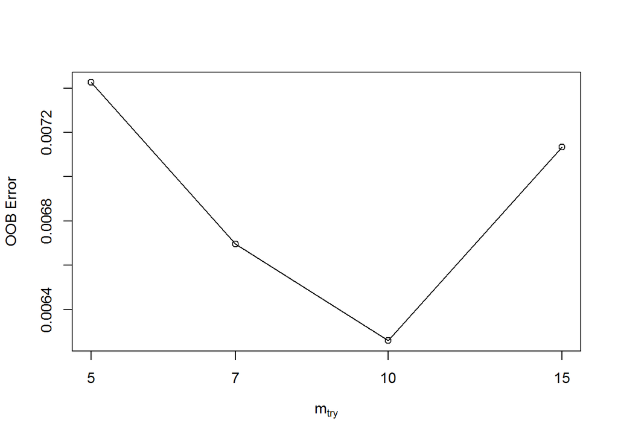

```r
library(randomForest)
speedUpRF <- tuneRF(training[-53],training$classe, ntreeTry=100,stepFactor=1.5,improve=0.01, trace=TRUE, plot=TRUE, dobest=FALSE)
```

So we make our second trial using `randomForest()`, and according to this output we set `mtry=10`, again saving the processing time.

```r
initTime   <- proc.time()
modFitRF <-randomForest(classe~.,data=training, mtry=10, ntree=100,keep.forest=TRUE, importance=TRUE,test=testing)
randomForestTime  <- proc.time() - initTime
randomForestTime
```

```
##    user  system elapsed
##   14.65    0.00   14.65
```

It turns out that this alternative method is 28.3 times faster than the use that we made of `train()`!

Again, just to be sure that this new model is good, we check the out-of-sample error.

```r
testingPredictRF <- predict(modFitRF, newdata=testing)
confusionMatrix(testing$classe, testingPredictRF)
```

```
## Confusion Matrix and Statistics
##
##           Reference
## Prediction    A    B    C    D    E
##          A 1672    1    1    0    0
##          B    4 1133    2    0    0
##          C    0    2 1022    2    0
##          D    0    0   13  951    0
##          E    0    0    1    2 1079
##
## Overall Statistics
##
##                Accuracy : 0.9952
##                  95% CI : (0.9931, 0.9968)
##     No Information Rate : 0.2848
##     P-Value [Acc > NIR] : < 2.2e-16
##
##                   Kappa : 0.994
##  Mcnemar's Test P-Value : NA
##
## Statistics by Class:
##
##                      Class: A Class: B Class: C Class: D Class: E
## Sensitivity            0.9976   0.9974   0.9836   0.9958   1.0000
## Specificity            0.9995   0.9987   0.9992   0.9974   0.9994
## Pos Pred Value         0.9988   0.9947   0.9961   0.9865   0.9972
## Neg Pred Value         0.9991   0.9994   0.9965   0.9992   1.0000
## Prevalence             0.2848   0.1930   0.1766   0.1623   0.1833
## Detection Rate         0.2841   0.1925   0.1737   0.1616   0.1833
## Detection Prevalence   0.2845   0.1935   0.1743   0.1638   0.1839
## Balanced Accuracy      0.9986   0.9980   0.9914   0.9966   0.9997
```

```r
testing$predWrongRF <- testingPredictRF != testing$classe
sum(testing$predWrongRF) / length(testingPredictRF)
```

```
## [1] 0.004757859
```

The error rate is even smaller!

We conclude the analysis plotting a summary of the variable importance, according to mean decrease in accuracy and mean decrease in Gini.

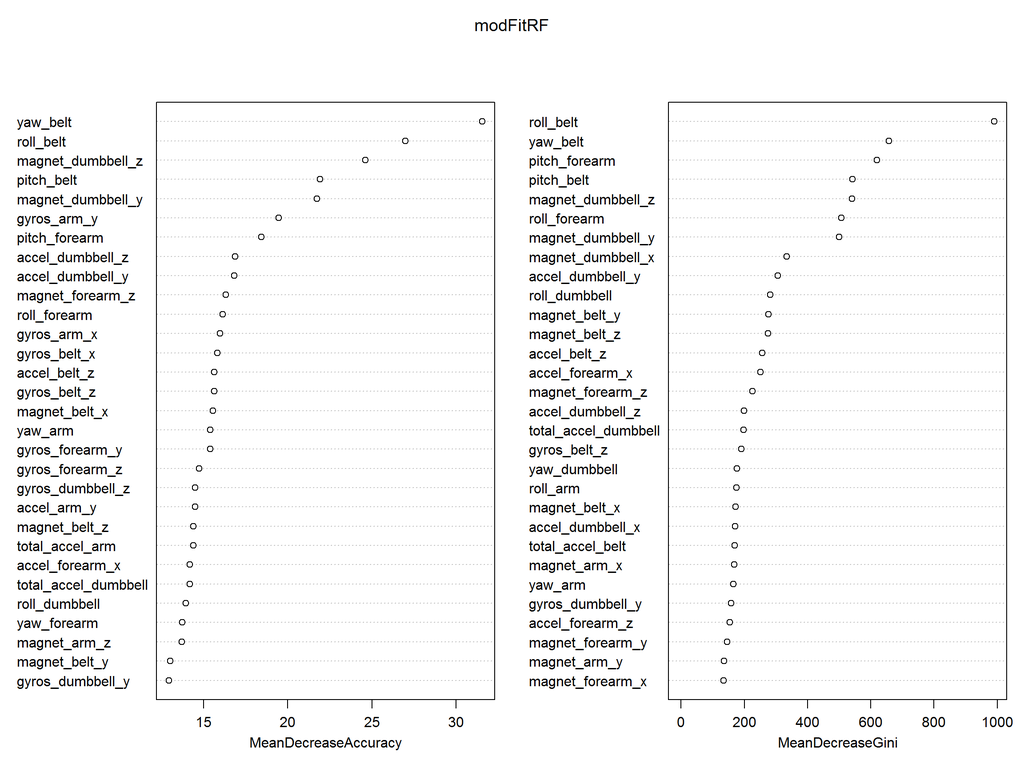

```r
varImpPlot(modFitRF)
```